# Lecture 8-1: Functions of Functions

## Previously we focused on…

- Writing our own functions.
- Dividing labor with multiple functions.
- Using `apply`, `sapply`, etc., to avoid iteration.

## Agenda

- Functions are objects in R, just like everything else.
- Functions can be arguments to other functions and also returned by other functions.

## R Functions That Take Functions as Arguments

- `apply()`, `sapply()`, `ddply()` etc.: Takes a function and applies it on some objects (rows/columns of a matrix, elements of a list).
- `optim()` takes a function and returns a value for its input that minimizes it. I.e. finds argmin_x( f(x) )
- `curve()`: Evaluate a function over a range, plots the results.

## Anonymous Functions

- `function()` returns an object of class `function`.

```r
foo <- function() {}
class(foo)
```

```
## [1] "function"
```

- So far we’ve assigned that object to a name.
- If we don’t have an assignment, we get an **anonymous function**.
- Usually part of some larger expression:

```r
sapply( (-2):2, function(x) { exp(x) / (1 + exp(x)) } )
```

```
## [1] 0.1192029 0.2689414 0.5000000 0.7310586 0.8807971
```

- Often handy when connecting other pieces of code, especially in the functions such as `apply` and `sapply`.
- Won’t clutter the workspace.
- Can’t be examined or re-used later.

## Functions that take functions as input and return vectors

### Gradient of a Function

- Problems in statistics sometimes boil down to optimization.
- Lots of optimization problems require the gradient of the **objective function**.
- Gradient of $f: R^n -> R$ at $x$:

Given $f\colon \mathbf {R} ^{n}\to \mathbf {R}$ its gradient $\nabla f\colon \mathbf {R} ^{n}\to \mathbf {R} ^{n}$ is given by
$$\nabla f(x) = \left[\frac{\partial f}{\partial x_1}(x) \, \ldots \, \frac{\partial f}{\partial x_p}(x)\right]$$

- We do the same thing to get the gradient of $f$ at $x$ no matter what $f$ is:

```
  find the partial derivative of f with respect to each component of x
  return the vector of partial derivatives.
```

- It makes no sense to re-write this every time we change $f$. Therefore, we write code to calculate the gradient of an arbitrary function.

## Writing Our Own Gradient Function

- Use the simplest possible method: change `x` by some amount, find the difference in `f`, compute the slope.
- Pseudo-code:

```r
gradient <- function(function f, numeric x, numeric deriv_steps) {
  define empty gradient vector

  coordinate 1:
    new_x <- x
    new_x[1] <- new_x[1] + deriv_steps[1]
    gradient[1] <- ( f(x_new) - f(x) ) / ( x_new[1] - x[1] )
    # Or better: substitute (x_new[1] - x[1]) by (deriv_steps[1])

  coordinate 2:
    new_x <- x
    new_x[2] <- new_x[2] + deriv_steps[2]
    gradient[2] <- ( f(x_new) - f(x) ) / ( deriv_steps[2] )

  return(gradient)
}
```

- An implementation using a `for` loop:

```r
gradient <- function(f, x, deriv_steps, ...) {
  p <- length(x)
  stopifnot(length(deriv_steps) == p)
  gradient <- numeric(p)
  for (i in 1:p) {
    x_new <- x
    x_new[i] <- x_new[i] + deriv_steps[i]
    gradient[i] <- ( f(x_new, ...) - f(x, ...) ) / deriv_steps[i]
  }
  return(gradient)
}
```

(any extra arguments to `gradient` will get passed to `f` via `...`)

Let $f(x1, x2) = sin(x1) + cos(x2)$. Then $\nabla f = [ cos(x1), -sin(x2) ]$. Test our function!

First, define $f$:

```r
foo <- function(x) {
  return( sin(x[1]) + cos(x[2]) )
}
```

Then, select an $x$ value:

```r
x <- runif(2)
```

Compute the gradient:

```r
gradient(f = foo, x = x, deriv_steps = c(1e-6, 1e-6))
```

```
## [1]  0.8345953 -0.5281186
```

And compare to the analytic gradient function evaluated at `x`:

```r
c(cos(x[1]), -sin(x[2]))
```

```
## [1]  0.8345956 -0.5281182
```

```r
all.equal(
  gradient(f = foo, x = x, deriv_steps = c(1e-6, 1e-6)),
  c(cos(x[1]), -sin(x[2])),
  tolerance = 1e-5
  )
```

```
## [1] TRUE
```

Exercise: Define $f$ to be some polynomial function. Check that our gradient function works for this function as well.

Answer: Let

$g(x) = -8 + x_1 + 2x_2^2 - 5x_3^3$

Then

$\nabla g(x) = [ 1, 4x_2, -15x_3^2 ]$

```r
goo <- function(x) {
  -8 + x[1] + 2 * x[2]^2 - 5 * x[3] ^3
}
x <- runif(3)
gradient(goo, x, deriv_steps = rep(1e-6, 3))
```

```
## [1]  1.000000  1.974833 -5.995712
```

```r
# and compare to:
c(1, 4 * x[2], -15 * x[3]^2)
```

```
## [1]  1.000000  1.974831 -5.995703
```

- We can potentially use matrix manipulation and `apply`:

```r
gradient_matrix_based <- function(f, x, deriv_steps, ...) {
  p <- length(x)
  stopifnot(length(deriv_steps) == p)
  x_new <- matrix(rep(x, times = p), nrow = p) + diag(deriv_steps, nrow = p)
  f_new <- apply(x_new, 2, f, ...)
  gradient <- (f_new - f(x, ...)) / deriv_steps
  return(gradient)
}

gradient_matrix_based(goo, x, deriv_steps = rep(1e-6, 3))
```

```
## [1]  1.000000  1.974833 -5.995712
```

## To Improve

- Will act badly if `f` is only defined on a limited domain and we ask for the gradient somewhere near a boundary.
- Forces the user to choose `deriv_steps`.
- Uses the same `deriv_steps` everywhere, imagine $f(x) = x^2 / sin{x}$.

As is often the case, there are packages in R that perform computations for us.

## `numDeriv::grad()`

```r
grad(func, x, ...)
```

- Assumes `func` is a function which returns a single floating-point value.
- Assumes `x` is a vector of arguments to `func`. If `x` is a vector and `func(x)` is also a vector, then it’s assumed `func` is vectorized and we get a vector of derivatives.
- Extra arguments in `...` get passed along to `func`.

Exercise:

What is the default method for `grad()`?

One of the methods for `grad()` computes the gradient in exactly the same way that we did. Which method is that? Show that we get the same results (you might need to use the `method.args` parameter).

Answer: - The default method is “Richardson” - `method = "simple"` with `args = list(eps = 1e-6)` will do what we did:

```r
x = runif(2)
numDeriv::grad(foo, x)
```

```
## [1]  0.9980088 -0.1927642
```

```r
numDeriv::grad(foo, x, method = "simple", method.args = list(eps = 1e-6))
```

```
## [1]  0.9980088 -0.1927647
```

```r
gradient(f = foo, x = x, deriv_steps = c(1e-6, 1e-6))
```

```
## [1]  0.9980088 -0.1927647
```

- Other functions in the package compute the Jacobian of a vector-valued function, and the matrix of second partials (Hessian).
- Smart and advanced R users know when to use external packages wisely, but also have the gumption to write their own functions when needed (or extract/modify external code according to need).

So far, we have taken a function as input and returned a vector as output. But, we can also return functions as output.

## Functions That Take Functions or Expressions as Inputs

Example: `curve()`

- A call to `curve` looks like this:

curve(expr, from = a, to = b, n = 101, …)

Where `expr` is some expression involving a variable called `x` which is swept `from` the value `a` `to` the value `b` in `n` steps, `...` are other plot-control arguments.

- The inputs for `curve` are an expression (which is the name of a function, or a call or an expression written as a function of x) which will evaluate to an object of length n.

For example:

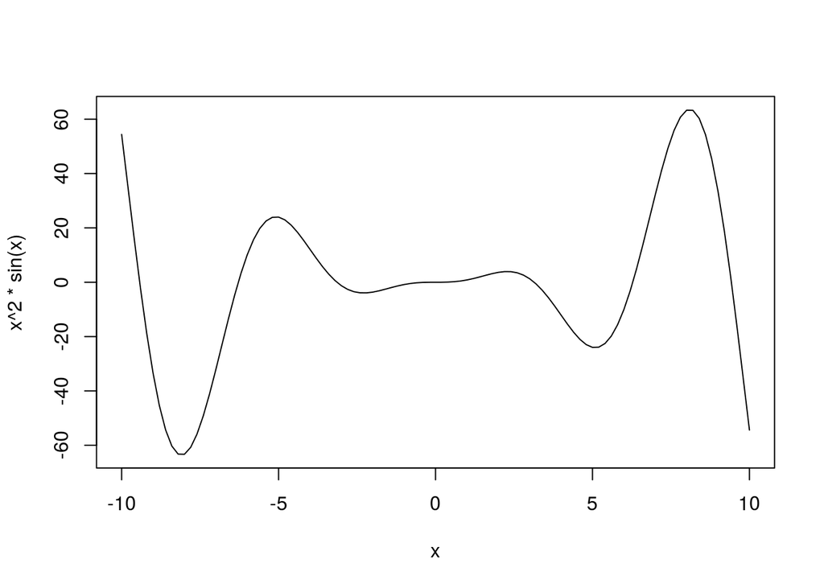

```r
a <- curve(x^2 * sin(x), from = -10, to = 10)
```

## Using `curve()` with our own functions

- If we have defined a function already, we can use it in `curve`:

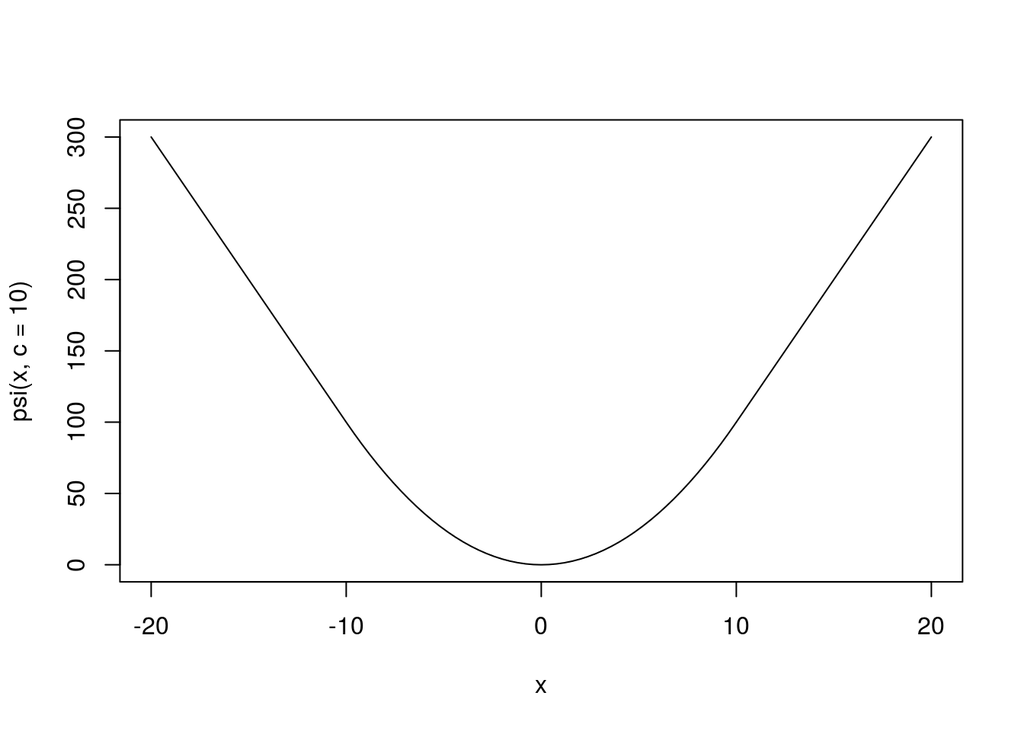

```r
psi <- function(x, c = 1) {
  return (
    ifelse(
    abs(x) > c,
    2 * c * abs(x) - c^2,
    x^2
    )
  )
}
curve(psi(x, c = 10), from = -20, to = 20)
```

Exercise: What is the following line doing?

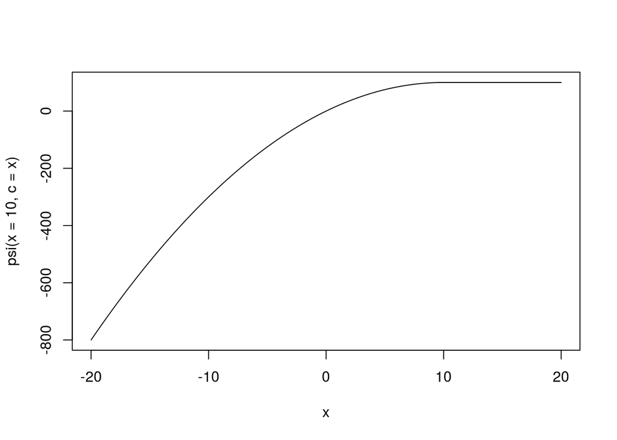

```r
curve(psi(x = 10, c = x), from = -20, to = 20)
```

And what is the following line doing?

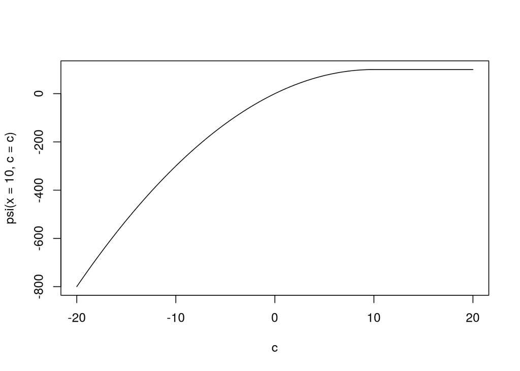

```r
curve(psi(x = 10, c = c), from = -20, to = 20, xname = "c")
```

Answer: Since curve is taking an expression as a function of x, it keeps x of psi at 10, and c goes between -20 and 20. The following more explicit line will do the same:

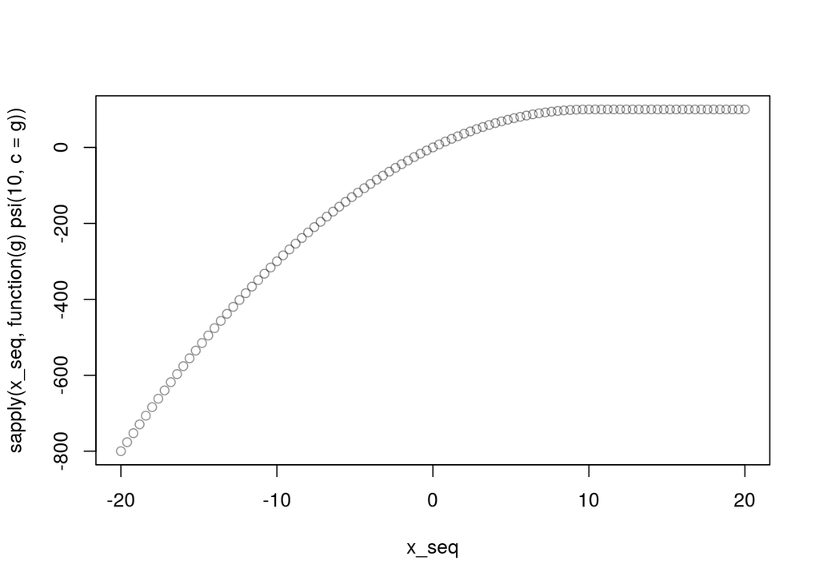

```r
x_seq <- seq(from = -20, to = 20, length.out = 101)
plot(x_seq, sapply(x_seq, function(g) psi(10, c = g)), col = rgb(0, 0, 0, 0.4))
```

- If our function doesn’t take vectors to vectors, `curve` does not work:

```r
gmp <- read.table("gmp.dat")
head(gmp)
```

```
##                           MSA        gmp pcgmp
## 1                 Abilene, TX 3.8870e+09 24490
## 2                   Akron, OH 2.2998e+10 32889
## 3                  Albany, GA 3.9550e+09 24269
## 4 Albany-Schenectady-Troy, NY 3.1321e+10 36836
## 5             Albuquerque, NM 3.0727e+10 37657
## 6              Alexandria, LA 3.8790e+09 25494
```

GMP stands for Gross Metropolitan Product

PCGMP for Per Capita GMP

So to compute the population size in a metropolitan area:

```r
gmp$pop <- round(gmp$gmp / gmp$pcgmp)
```

Suppose that we think that there is a power law that relates population size to PCGMP (see https://www.ncbi.nlm.nih.gov/pmc/articles/PMC1852329/ for similar ideas),

i.e. $PCGMP = y0 \cdot (\text{population_size})^a$

Suppose next that we want to plot the curve of the MSE for different `y0` and `a` values. The MSE for a general power law is given by:

Exercise: Write an MSE function for a general power law, Y = y0 * N^a

```r
mse_power_law <- function(y0, a, Y, N) {
   return( mean( ( Y - y0 * (N^a) )^2 ) )
}
```

Try it:

```r
mse_power_law(y0 = 6611, a = 0.1, Y = gmp$pcgmp, N = gmp$pop)
```

```
## [1] 154701953
```

Let us use `curve` to plot the MSE over a range of `a` values from 0.1 to 0.15:

```r
curve(
  mse_power_law(a = x, y0 = 6611, Y = gmp$pcgmp, N = gmp$pop),
  from = 0.10,
  to = 0.15
  )
```

```
## Error in curve(mse_power_law(a = x, y0 = 6611, Y = gmp$pcgmp, N = gmp$pop), : 'expr' did not evaluate to an object of length 'n'
```

We get an error message: even though the form is similar to our previous example, `curve` only works where the `x` input is a vector. This isn’t the case for our MSE function (it is a scalar function)

How do we solve this?

- Define a new, vectorized function, say with `sapply`:

```r
a_seq <- seq(from = 0.10, to = 0.15, by = 0.01)
sapply(a_seq, mse_power_law, y0 = 6611, Y = gmp$pcgmp, N = gmp$pop)
```

```
## [1] 154701953 102322974  68755654  64529166 104079527 207057513
```

And then wrap it in a function:

```r
mse_power_law_sapply <- function(a_seq, ...) {
  return( sapply(a_seq, mse_power_law, ...))
}
mse_power_law_sapply(seq(from = 0.10, to = 0.15, by = 0.01), y0 = 6611, Y = gmp$pcgmp, N = gmp$pop)
```

```
## [1] 154701953 102322974  68755654  64529166 104079527 207057513
```

Now we can use this with

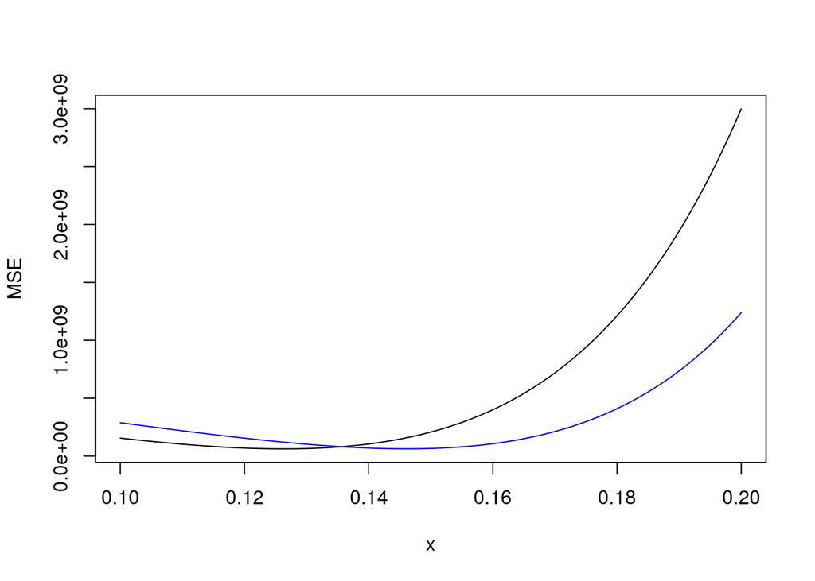

```r
curve(
  mse_power_law_sapply(a = x, y0 = 6611, Y = gmp$pcgmp, N = gmp$pop),
  from = 0.10,
  to = 0.20,
  xlab = "x",
  ylab = "MSE"
  )
curve(
  mse_power_law_sapply(a = x, y0 = 5100, Y = gmp$pcgmp, N = gmp$pop),
  add = TRUE,
  col = "blue"
  )
```

- Alternate strategy: `Vectorize()` returns a new, vectorized function, in the same fashion that we used above. However, it is a little more robust and allows multiple arguments to be vectorized easily:

```r
mse_power_law_vec <- Vectorize(mse_power_law, vectorize.args = c("y0", "a"))
mse_power_law_vec(a = seq(from = 0.10, to = 0.15, by = 0.01), y0 = 6611, Y = gmp$pcgmp, N = gmp$pop)
```

```
## [1] 154701953 102322974  68755654  64529166 104079527 207057513
```

```r
mse_power_law_vec(a = 1/8, y0 = c(5000, 6000, 7000), Y = gmp$pcgmp, N = gmp$pop)
```

```
## [1] 134617132  74693733  63732256
```

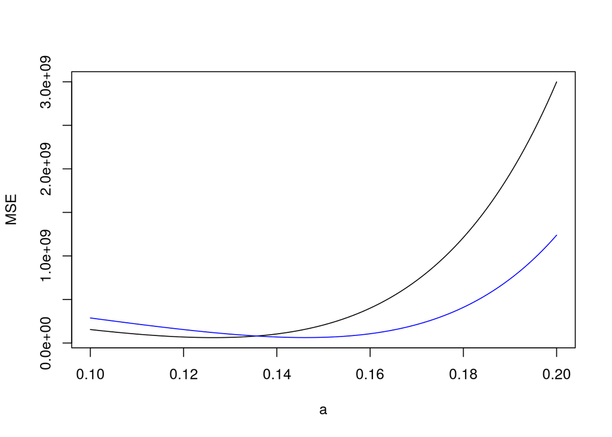

```r
curve(
  mse_power_law_vec(a = x, y0 = 6611, Y = gmp$pcgmp, N = gmp$pop),
  from = 0.10,
  to = 0.20,
  xlab = "a",
  ylab = "MSE"
  )
curve(
  mse_power_law_vec(a = x, y0 = 5100, Y = gmp$pcgmp, N = gmp$pop),
  add = TRUE,
  col = "blue"
  )
```

## Example: surface function

- `curve()` takes an expression and plots a 1-D curve by sweeping over `x`.
- We may want to plot by sweeping over two variables, having `z` computed as a function of `x` and `y` at an expression or function we provide.

We can build on the built-in plotting function `contour()`:

```r
contour(x,y,z, [[other stuff]])
```

where `x` and `y` are vectors of coordinates, `z` is a matrix of the corresponding shape. (see `help(contour)` for graphical options.)

- Strategy: `contour_fn()` should make `x` and `y` sequences, evaluate the expression at each combination to get `z`, and then call `contour`.

## First version: `contour_fn()`

Ingredients:

```r
(g <- expand.grid(1:3, 5:8))
```

```
##    Var1 Var2
## 1     1    5
## 2     2    5
## 3     3    5
## 4     1    6
## 5     2    6
## 6     3    6
## 7     1    7
## 8     2    7
## 9     3    7
## 10    1    8
## 11    2    8
## 12    3    8
```

```r
mapply(FUN = `*`, g[ , 1], g[ , 2])
```

```
##  [1]  5 10 15  6 12 18  7 14 21  8 16 24
```

- Only works with vector-to-number $\mathbf{R}^2 -> \mathbf{R}$ functions:

```r
contour_fn <- function(f, from_x = 0, to_x = 1, from_y = 0, to_y = 1, n_x = 101, n_y = 101, ...) {
  x_seq <- seq(from = from_x, to = to_x, length.out = n_x)
  y_seq <- seq(from = from_y, to = to_y, length.out = n_y)
  plot_grid <- expand.grid(x = x_seq, y = y_seq)
  z_values <- mapply(FUN = f, plot_grid$x, plot_grid$y)
  z_matrix <- matrix(z_values, nrow = n_x)
  contour(x = x_seq, y = y_seq, z = z_matrix, ...)
  return(invisible(list(x = x_seq, y = y_seq, z = z_matrix)))
}
```

We can call our function with anonymous and named functions:

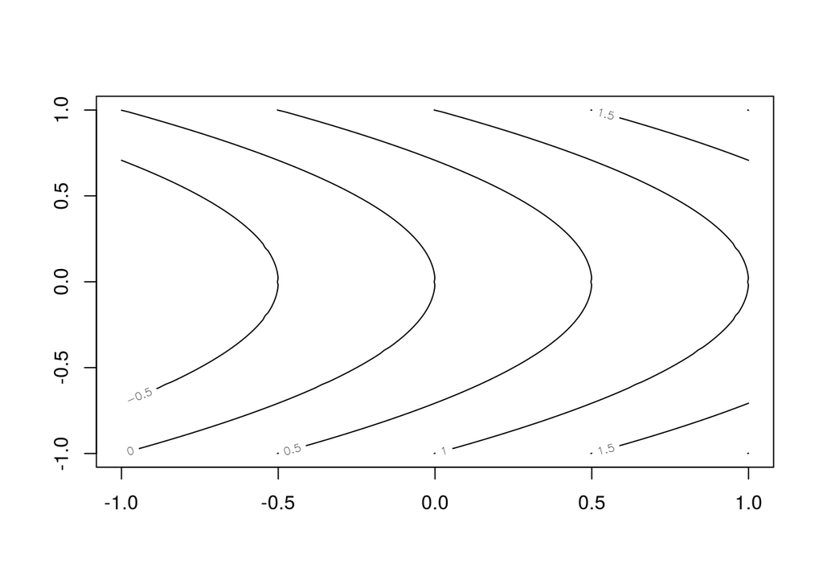

```r
contour_fn(function(x, y) {x + abs(y^2)}, from_x = -1, from_y = -1)
```

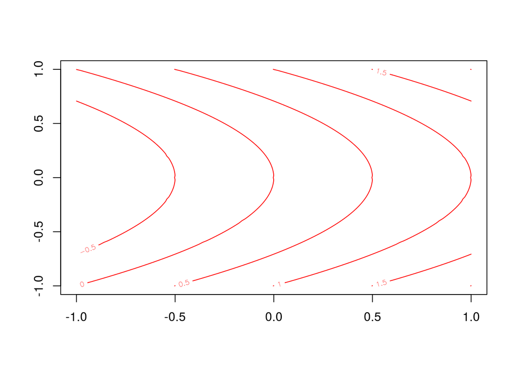

```r
xy_fn <- function(x, y) {x + abs(y^2)}
contour_fn(xy_fn, from_x =-1, from_y = -1, col = "red")
```

## Expressions and Evaluation

- Recall our first example with `curve()`:

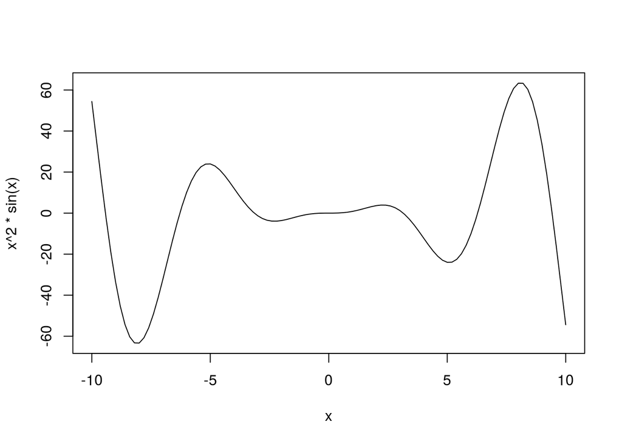

```r
curve(x^2 * sin(x), from = -10, to = 10)
```

- I.e. `curve` doesn’t require us to write a function every time — what’s its trick?
- **Expressions** are just another class of R objects, they can be created and manipulated.
- One manipulation is **evaluation**.

```
eval(expr, envir)
```

Evaluates the expression `expr` in the environment `envir`, which can be a data frame or even just a list.

- When we type something like `x^2 + y^2` as an argument to `contour_fn`, R tries to evaluate it directly.
- `substitute` returns the *unevaluated* expression.
- `curve` uses first `substitute(expr)` and then `eval(expr,envir)`, having made the right `envir`.

Example:

```r
unevaluated_expression <- substitute(x + y^2)
unevaluated_expression
```

```
## x + y^2
```

```r
eval(unevaluated_expression, envir = list(x = 5, y = 3))
```

```
## [1] 14
```

```r
eval(unevaluated_expression, envir = list(x = c(1, 2), y = c(1, 2)))
```

```
## [1] 2 6
```

```r
(grid <-
  expand.grid(
    x = seq(from = 1, to = 3, length.out = 3),
    y = seq(from = 2, to = 4, length.out = 3)
    ))
```

```
##   x y
## 1 1 2
## 2 2 2
## 3 3 2
## 4 1 3
## 5 2 3
## 6 3 3
## 7 1 4
## 8 2 4
## 9 3 4
```

```r
eval(unevaluated_expression, envir = grid)
```

```
## [1]  5  6  7 10 11 12 17 18 19
```

## Second version: `contour_expr()`

Exercise: Use the above functions to modify our `contour_fn` function to a new function called `contour_expr` that takes expressions as inputs

Answer:

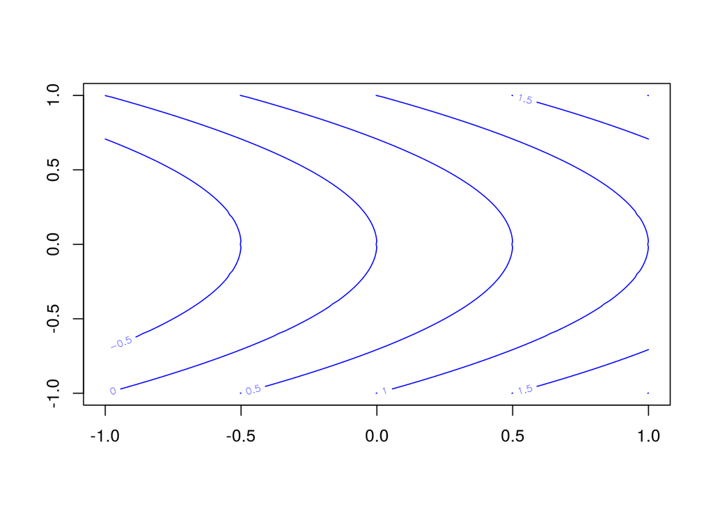

```r
contour_expr <- function(expr, from_x = 0, to_x = 1, from_y = 0, to_y = 1, n_x = 101, n_y = 101, ...) {
  x_seq <- seq(from = from_x, to = to_x, length.out = n_x)
  y_seq <- seq(from = from_y, to = to_y, length.out = n_y)
  plot_grid <- expand.grid(x = x_seq, y = y_seq)
  unevaluated_expression <- substitute(expr)
  z_values <- eval(unevaluated_expression, envir = plot_grid)
  z_matrix <- matrix(z_values, nrow = n_x)
  contour(x = x_seq, y = y_seq, z = z_matrix, ...)
  invisible(list(x = x_seq, y = y_seq, z = z_matrix))
}

contour_expr(x + abs(y^2), from_x = -1, from_y = -1, col = "blue")
```

# But…

```r
ggg <- function(x, y) { x + abs(y^2) }
contour_expr(ggg, from_x = -1, from_y = -1)
```

```
## Error in as.vector(x, mode): cannot coerce type 'closure' to vector of type 'any'
```

Third version: Handle Both Functions and Expressions by Converting Expressions to Functions

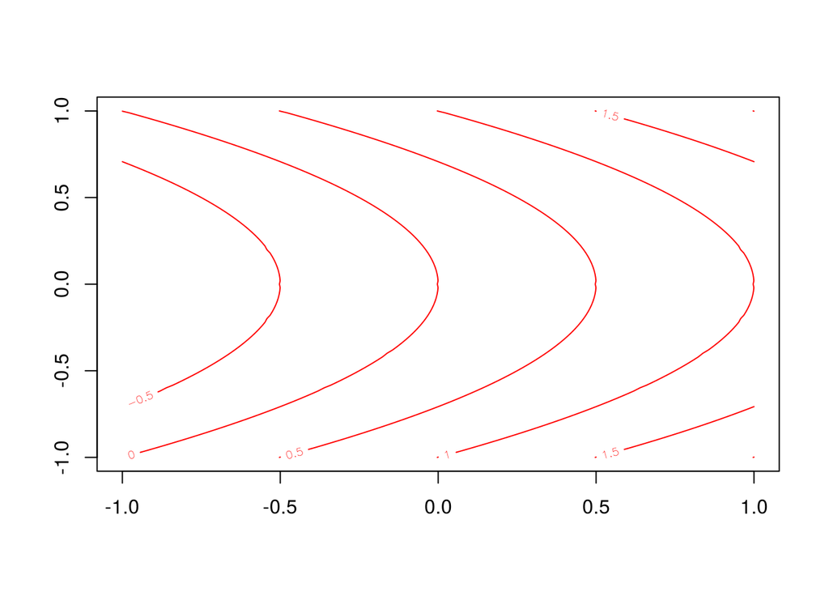

```r
contour_fn_expr <- function(expr, from_x = 0, to_x = 1, from_y = 0, to_y = 1, n_x = 101, n_y = 101, ...) {
  sexpr <- substitute(expr)
  dexpr <- deparse(sexpr)
  if (is.name(sexpr) | any(stringr::str_detect(dexpr, "function"))) {
    contour_fn(expr, from_x = from_x, to_x = to_x, from_y = from_y, to_y = to_y, n_x = n_x, n_y = n_y, ...)
  } else {
    expr <- substitute(expr)
    f <- rlang::new_function(rlang::exprs(x = , y = ), expr)
    contour_fn(f, from_x = from_x, to_x = to_x, from_y = from_y, to_y = to_y, n_x = n_x, n_y = n_y, ...)
  }
}

contour_fn_expr(x + abs(y^2), from_x = -1, from_y = -1, col = "red")
contour_fn_expr(function(x, y) { x + abs(y^2) }, from_x = -1, from_y = -1, col = "red")
```

[output not shown]

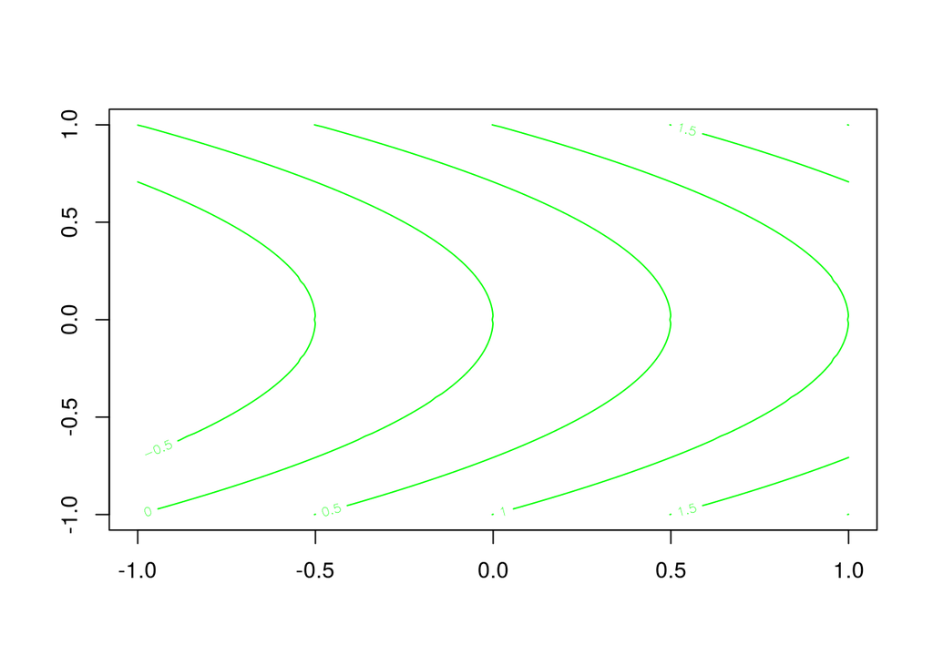

```r
contour_fn_expr(ggg, from_x = -1, from_y = -1, col = "green")
```

## Functions of Functions: Mathematically

- Maximum, and location of the maximum: takes $f$, gives number:
  $$\DeclareMathOperator*{\argmax}{argmax}
  \max_{x}{f(x)} ~, ~ \argmax_{x}{f(x)}.$$
- Derivative of $f$ at $x_0$: takes a function and a point, gives a number:
  $$\frac{df}{dx}(x_0) \equiv \lim_{h\rightarrow 0}{\frac{f(x_0+h) - f(x_0)}{h}}.$$
- Definite integral of $f$ over $[a,b]$: takes a function and two points, gives a number:
  $$\int_{a}^{b}{f(x) dx} \equiv \lim_{n\rightarrow
  \infty}{\sum_{i=0}^{n-1}{\left(\frac{b-a}{n}\right)f\left(a+i\frac{b-a}{n}\right)}}.$$
- Functions of functions which return numbers are called **functionals**, e.g., expectation values:
  $$\mathbb{E}[f(X)] \equiv \int_{\mathrm{all}~x}{f(x) p(x) dx}.$$
- $\nabla f(x_0)$ takes $f$ and $x_0$, gives vector: not strictly a functional.
- $\nabla f$ is another, vector-valued function.
- $\nabla$ takes a function and returns a function. It is an **operator**, not a functional.

Something which takes a function in and gives a function back is an **operator**.
- Differentiation: the operator $d/dx$ takes $f$ and gives a new function.
- Gradient: the operator $\nabla$ takes $f$ and gives a new function.
Similarly $\nabla \cdot$, $\nabla \times$, …
- Indefinite integration: $\int_{-\infty}^{x}{f(u) du}$ takes $f$ and gives a new function.
- Fourier transform: takes $f$ and gives a new function
$$\tilde{f}(\omega) = \int_{x=-\infty}^{x=\infty}{f(x) e^{2i\pi \omega x} dx}.$$

## Returning Functions in R

A function has three parts:

- formals(), a list of arguments that control how you call the function.
- body(), the code inside the function.
- environment(), the data structure that determines how the function finds the values associated with the names.

`` formals`` and ``body`` are specified explicitly when you create a function, the environment is specified implicitly, based on where you defined the function. A function takes values for all names which aren’t its arguments from the environment where it was defined, not the one where it is called. The function environment always exists, but it is only printed when the function isn’t defined in the global environment.

## Returning Functions: A trivial example

Functions can be return values like anything else.

```r
make_circumference_fn <- function(ratio_to_diameter = pi) {
  circumference <- function(d) {
    return(ratio_to_diameter * d)
  }
  return(circumference)
}


circ3 <- make_circumference_fn(3)
circ3(10)
```

```
## [1] 30
```

```r
formals(circ3)
```

```r
body(circ3)
```

```
## {
##     return(ratio_to_diameter * d)
## }
```

```r
environment(circ3)
```

```
## <environment: 0x2a06180>
```

```r
ls(environment(circ3))
```

```
## [1] "circumference"     "ratio_to_diameter"
```

```r
environment(circ3)$circumference
```

```
## function(d) {
##     return(ratio_to_diameter * d)
##   }
## <environment: 0x2a06180>
```

```r
# (bytecode is a pointer to a compiled version of the body of the function)
environment(circ3)$ratio_to_diameter
```

```
## [1] 3
```

```r
circ4 <- make_circumference_fn(4)
environment(circ4)
```

```
## <environment: 0xefd500>
```

```r
ls(environment(circ4))
```

```
## [1] "circumference"     "ratio_to_diameter"
```

```r
environment(circ4)$circumference
```

```
## function(d) {
##     return(ratio_to_diameter * d)
##   }
## <bytecode: 0x1582898>
## <environment: 0xefd500>
```

```r
environment(circ4)$ratio_to_diameter
```

```
## [1] 4
```

## Returning a function: a bad example

To exemplify the scoping behavior in R, let’s look at the following function:

```r
bad_fn <- function(x) {
  return( x + y )
}
```

We haven’t defined `y` within `bad_fn`, but still there is no error message. We only get an error message when we call the function:

```r
bad_fn(10)
```

```
## Error in bad_fn(10): object 'y' not found
```

But, if y was defined in the global environment, R takes that value:

```r
y <- 100
bad_fn(10)
```

```
## [1] 110
```

```r
y <- 1000
bad_fn(10)
```

```
## [1] 1010
```

Although convenient for casual scripting, this behavior is typically not recommended for your functions, especially if those serve as an output from another function.

## Returning a function: a Less Trivial Example

Create a linear predictor, based on values of two variables.

Ingredients:

to perform a simple linear regression:

Make some data:

```r
x <- runif(30)
y <- 2 + 8 * x + rnorm(30)
par(mar = c(3, 3, 1, 1))
plot(x, y)
#  Fit a simple linear regression (y_i = beta_0 + beta_1 * x_i + epsilon_i):
lm(y ~ x)
```

```
##
## Call:
## lm(formula = y ~ x)
##
## Coefficients:
## (Intercept)            x
##       1.744        8.294
```

```r
lm_fit <- lm(y ~ x)

# Note
lm_fit$model
```

```
##            y           x
## 1  8.4897507 0.867082875
## 2  3.2963929 0.385314267
## 3  5.7441015 0.345494135
## 4  4.6025851 0.459907090
## 5  0.7221209 0.007171364
## 6  4.0316983 0.496277686
## 7  4.2035244 0.153383347
## 8  4.7338156 0.197785552
## 9  2.8997573 0.152349862
## 10 5.4962028 0.182564601
## 11 3.9013207 0.413835216
## 12 2.9952092 0.361573994
## 13 1.7708213 0.149221484
## 14 1.3560156 0.062296803
```

[output cut: 16 more lines]

```r
# stores the original data in the output. We can use `lm` with the option `model = FALSE`
# to negate that:
lm_fit <- lm(y ~ x, model = FALSE)
lm_fit$model
```

```r
beta0 <- coef(lm_fit)[1]
beta1 <- coef(lm_fit)[2]
abline(a = beta0, b = beta1)
# Predict points on curve given the same x values:
beta0 + beta1 * x
```

```
##  [1] 8.936269 4.940363 4.610085 5.559054 1.803954 5.860721 3.016672
##  [8] 3.384954 3.008100 3.258708 5.176923 4.743455 2.982152 2.261178
## [15] 8.614739 7.060783 9.404890 2.426154 5.262177 9.658804 8.152768
## [22] 6.759092 4.808390 6.153146 2.212033 5.114060 2.963641 7.090332
## [29] 6.980664 8.006403
```

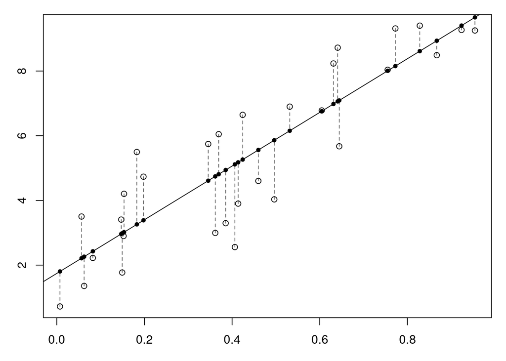

```r
points(x, beta0 + beta1 * x, pch = 20)
segments(x, y0 = y, y1 = beta0 + beta1 * x, lty = 2, col = rgb(0, 0, 0, 0.6))
```

Exercise: define a function that, based on these data, returns a predictor function (do not use the built-in `predict()`)

Answer:

```r
make_linear_predictor <- function(x, y) {
  linear_fit <- lm(y ~ x, model = FALSE)
  beta0 <- coef(linear_fit)[1]
  beta1 <- coef(linear_fit)[2]
  predictor <- function(new_data) {
    return( unname( beta0 + beta1 * new_data ) )
  }
  return(predictor)
}
```

The predictor function persists and works, even when the data we used to create it is gone:

```r
library(MASS)
```

Bwt = Body weight Hwt = Heart weight

```r
vet_predictor <- make_linear_predictor(x = cats$Bwt, y = cats$Hwt)
vet_predictor
```

```
## function(new_data) {
##     return( unname( beta0 + beta1 * new_data ) )
##   }
## <environment: 0x2921cb0>
```

```r
detach(package:MASS)
cats$Bwt
```

```
## Error in eval(expr, envir, enclos): object 'cats' not found
```

```r
cats$Hwt
```

```
## Error in eval(expr, envir, enclos): object 'cats' not found
```

```r
vet_predictor(3.5)  # My cat's body mass in kilograms
```

```
## [1] 13.76256
```

```r
formals(vet_predictor)
```

```r
body(vet_predictor)
```

```
## {
##     return(unname(beta0 + beta1 * new_data))
## }
```

What happens if we define `linear_fit` in the global environment?

```r
linear_fit <- lm(rep(1, 10) ~ seq(1:10))
linear_fit
```

```
##
## Call:
## lm(formula = rep(1, 10) ~ seq(1:10))
##
## Coefficients:
## (Intercept)    seq(1:10)
##           1            0
```

```r
vet_predictor(3.5)
```

```
## [1] 13.76256
```

Nothing, because `linear_fit` was stored in the internal environment. R searches for `linear_fit` first in the internal environment, and only if it fails to find it there it searches for it in the global environment.

```r
ls(environment(vet_predictor))
```

```
## [1] "beta0"      "beta1"      "linear_fit" "predictor"  "x"
## [6] "y"
```

```r
environment(vet_predictor)$x
```

```
##   [1] 2.0 2.0 2.0 2.1 2.1 2.1 2.1 2.1 2.1 2.1 2.1 2.1 2.2 2.2 2.2 2.2 2.2
##  [18] 2.2 2.3 2.3 2.3 2.3 2.3 2.3 2.3 2.3 2.3 2.3 2.3 2.3 2.4 2.4 2.4 2.4
##  [35] 2.5 2.5 2.6 2.6 2.6 2.7 2.7 2.7 2.9 2.9 2.9 3.0 3.0 2.0 2.0 2.1 2.2
##  [52] 2.2 2.2 2.2 2.2 2.2 2.2 2.2 2.3 2.4 2.4 2.4 2.4 2.4 2.5 2.5 2.5 2.5
##  [69] 2.5 2.5 2.5 2.5 2.6 2.6 2.6 2.6 2.6 2.6 2.7 2.7 2.7 2.7 2.7 2.7 2.7
##  [86] 2.7 2.7 2.8 2.8 2.8 2.8 2.8 2.8 2.8 2.9 2.9 2.9 2.9 2.9 3.0 3.0 3.0
## [103] 3.0 3.0 3.0 3.0 3.0 3.0 3.1 3.1 3.1 3.1 3.1 3.1 3.2 3.2 3.2 3.2 3.2
## [120] 3.2 3.3 3.3 3.3 3.3 3.3 3.4 3.4 3.4 3.4 3.4 3.5 3.5 3.5 3.5 3.5 3.6
## [137] 3.6 3.6 3.6 3.7 3.8 3.8 3.9 3.9
```

```r
environment(vet_predictor)$y
```

```
##   [1]  7.0  7.4  9.5  7.2  7.3  7.6  8.1  8.2  8.3  8.5  8.7  9.8  7.1  8.7
##  [15]  9.1  9.7 10.9 11.0  7.3  7.9  8.4  9.0  9.0  9.5  9.6  9.7 10.1 10.1
##  [29] 10.6 11.2  6.3  8.7  8.8 10.2  9.0 10.9  8.7 10.1 10.1  8.5 10.2 10.8
##  [43]  9.9 10.1 10.1 10.6 13.0  6.5  6.5 10.1  7.2  7.6  7.9  8.5  9.1  9.6
##  [57]  9.6 10.7  9.6  7.3  7.9  7.9  9.1  9.3  7.9  8.6  8.8  8.8  9.3 11.0
##  [71] 12.7 12.7  7.7  8.3  9.4  9.4 10.5 11.5  8.0  9.0  9.6  9.6  9.8 10.4
##  [85] 11.1 12.0 12.5  9.1 10.0 10.2 11.4 12.0 13.3 13.5  9.4 10.1 10.6 11.3
##  [99] 11.8 10.0 10.4 10.6 11.6 12.2 12.4 12.7 13.3 13.8  9.9 11.5 12.1 12.5
## [113] 13.0 14.3 11.6 11.9 12.3 13.0 13.5 13.6 11.5 12.0 14.1 14.9 15.4 11.2
## [127] 12.2 12.4 12.8 14.4 11.7 12.9 15.6 15.7 17.2 11.8 13.3 14.8 15.0 11.0
## [141] 14.8 16.8 14.4 20.5
```

Let us then make a slimmer version:

```r
make_linear_predictor_slim <- function(x, y) {
  linear_fit <- lm(y ~ x, model = FALSE)
  beta0 <- coef(linear_fit)[1]
  beta1 <- coef(linear_fit)[2]
  rm(linear_fit, x, y)
  predictor <- function(new_data) {
    return( unname( beta0 + beta1 * new_data ) )
  }
  return(predictor)
}


vet_predictor_slim <- make_linear_predictor_slim(MASS::cats$Bwt, MASS::cats$Hwt)

vet_predictor_slim(3.5)
```

```
## [1] 13.76256
```

```r
all.equal(vet_predictor_slim(3.5), vet_predictor(3.5))
```

```
## [1] TRUE
```

```r
ls(environment(vet_predictor_slim))
```

```
## [1] "beta0"     "beta1"     "predictor"
```

Compare the results based on an inflated data set, where both `x` and `y` are repeated 100000 times.

```r
vet_predictor <- make_linear_predictor(x = rep(MASS::cats$Bwt, 100000), y = rep(MASS::cats$Hwt, 100000))
vet_predictor_slim <- make_linear_predictor_slim(x = rep(MASS::cats$Bwt, 100000), y = rep(MASS::cats$Hwt, 100000))

saveRDS(vet_predictor, "vet_predictor.rds")
file.info("vet_predictor.rds")$size
```

```
## [1] 4352069
```

```r
saveRDS(vet_predictor_slim, "vet_predictor_slim.rds")
file.info("vet_predictor_slim.rds")$size
```

```
## [1] 3023
```

This can be very useful with a large training set.

## A more mathematical example

- Instead of finding $\nabla f(x)$, find the function $\nabla f$:

```r
nabla <- function(f, ...) {
  grad_fn <- function(x, ...) {
    numDeriv::grad(func = f, x = x, ...)
  }
  return(grad_fn)
}
```

Exercise: Write a test case to see if this works.

An answer:

```r
x <- runif(2)

grad_fn <- nabla(foo)
(res1 <- grad_fn(x, method.args = list(eps = 1e-6), method = "simple"))
```

```
## [1]  0.9473619 -0.5027086
```

compare to:

```r
(res2 <- gradient(f = foo, x = x, deriv_steps = c(1e-6, 1e-6)))
```

```
## [1]  0.9473619 -0.5027086
```

```r
all.equal(res1, res2)
```

```
## [1] TRUE
```

## Summary

- In R, functions are objects, and can be arguments to other functions:
  - Use this to do the same thing to many different functions.
  - Separates writing the high-level operations and the first-order functions.
  - Use `sapply` (etc.), wrappers, anonymous functions as adapters.
- Functions can also be returned by other functions:
  - Variables other than the arguments to the function are fixed by the environment of creation.
  - Manipulating expressions lets us flexibly create functions.